# machine learning to predict exercise manner

Ming Tang

June 18, 2015

### Introduction

In this project, our goal will be to use data from accelerometers on the belt, forearm, arm, and dumbell of 6 participants. Six young health participants were asked to perform barbell lifts correctly and incorrectly in 5 different ways: exactly according to the specification (Class A), throwing the elbows to the front (Class B), lifting the dumbbell only halfway (Class C), lowering the dumbbell only halfway (Class D) and throwing the hips to the front (Class E).

The goal of your project is to predict the manner in which they did the exercise. This is the “classe” variable in the training set. The data for this project come from this [source](http://groupware.les.inf.puc-rio.br/har)

### Download the data and read the data into R

```r
trainingUrl<- "https://d396qusza40orc.cloudfront.net/predmachlearn/pml-training.csv"
testingUrl<- "https://d396qusza40orc.cloudfront.net/predmachlearn/pml-testing.csv"
download.file(trainingUrl, destfile = "pml-training.csv", method="curl")
download.file(testingUrl, destfile = "pml-testing.csv", method="curl")
training<- read.csv("pml-training.csv", stringsAsFactors = F)
testing<- read.csv("pml-testing.csv", stringsAsFactors = F)
```

### feature selection, Cross Validation and model buidling

```r
library(caret)
set.seed(333)
# let's look at the data first
str(training)
```

```
## 'data.frame':    19622 obs. of  160 variables:
##  $ X                       : int  1 2 3 4 5 6 7 8 9 10 ...
##  $ user_name               : chr  "carlitos" "carlitos" "carlitos" "carlitos" ...
##  $ raw_timestamp_part_1    : int  1323084231 1323084231 1323084231 1323084232 1323084232 1323084232 1323084232 1323084232 1323084232 1323084232 ...
##  $ raw_timestamp_part_2    : int  788290 808298 820366 120339 196328 304277 368296 440390 484323 484434 ...
##  $ cvtd_timestamp          : chr  "05/12/2011 11:23" "05/12/2011 11:23" "05/12/2011 11:23" "05/12/2011 11:23" ...
##  $ new_window              : chr  "no" "no" "no" "no" ...
##  $ num_window              : int  11 11 11 12 12 12 12 12 12 12 ...
##  $ roll_belt               : num  1.41 1.41 1.42 1.48 1.48 1.45 1.42 1.42 1.43 1.45 ...
##  $ pitch_belt              : num  8.07 8.07 8.07 8.05 8.07 8.06 8.09 8.13 8.16 8.17 ...
##  $ yaw_belt                : num  -94.4 -94.4 -94.4 -94.4 -94.4 -94.4 -94.4 -94.4 -94.4 -94.4 ...
##  $ total_accel_belt        : int  3 3 3 3 3 3 3 3 3 3 ...
##  $ kurtosis_roll_belt      : chr  "" "" "" "" ...
##  $ kurtosis_picth_belt     : chr  "" "" "" "" ...
##  $ kurtosis_yaw_belt       : chr  "" "" "" "" ...
```

[output cut: 86 more lines]

**the first column is the entry number, the second column is the user_name. Let’s remove them and some other non-sensor columns**

see discussion on [forum](https://class.coursera.org/predmachlearn-015/forum/thread?thread_id=41)  
Including the non-sensor columns will give you artifically high accuracy on your model, because they are highly correlated with the classe outcome.

```r
library(dplyr)
training<- select(training, c(-X,-user_name,-raw_timestamp_part_1, -raw_timestamp_part_2, -cvtd_timestamp, -new_window, -num_window))
testing<- select(testing, c(-X,-user_name,-raw_timestamp_part_1, -raw_timestamp_part_2, -cvtd_timestamp, -new_window, -num_window))

## turn all the character columns into numeric.

char_col_index<- sapply(training, class) == "character"

char_col<- names(training)[char_col_index]
char_col
```

```
##  [1] "kurtosis_roll_belt"      "kurtosis_picth_belt"
##  [3] "kurtosis_yaw_belt"       "skewness_roll_belt"
##  [5] "skewness_roll_belt.1"    "skewness_yaw_belt"
##  [7] "max_yaw_belt"            "min_yaw_belt"
##  [9] "amplitude_yaw_belt"      "kurtosis_roll_arm"
## [11] "kurtosis_picth_arm"      "kurtosis_yaw_arm"
## [13] "skewness_roll_arm"       "skewness_pitch_arm"
## [15] "skewness_yaw_arm"        "kurtosis_roll_dumbbell"
## [17] "kurtosis_picth_dumbbell" "kurtosis_yaw_dumbbell"
## [19] "skewness_roll_dumbbell"  "skewness_pitch_dumbbell"
## [21] "skewness_yaw_dumbbell"   "max_yaw_dumbbell"
## [23] "min_yaw_dumbbell"        "amplitude_yaw_dumbbell"
## [25] "kurtosis_roll_forearm"   "kurtosis_picth_forearm"
## [27] "kurtosis_yaw_forearm"    "skewness_roll_forearm"
## [29] "skewness_pitch_forearm"  "skewness_yaw_forearm"
## [31] "max_yaw_forearm"         "min_yaw_forearm"
## [33] "amplitude_yaw_forearm"   "classe"
```

```r
training<- training %>% mutate_each_(funs(as.numeric), char_col[-34])
testing<- testing %>% mutate_each_(funs(as.numeric), char_col[-34])

# some variables have no variability at all
# these variables are not useful when we want to construct a prediction modewhen the predictor nzv=TRUE, exclude it in the model

zeroV<- nearZeroVar(training,saveMetrics=TRUE)
zeroV
```

```
##                          freqRatio percentUnique zeroVar   nzv
## roll_belt                 1.101904    6.77810621   FALSE FALSE
## pitch_belt                1.036082    9.37722964   FALSE FALSE
## yaw_belt                  1.058480    9.97349913   FALSE FALSE
## total_accel_belt          1.063160    0.14779329   FALSE FALSE
## kurtosis_roll_belt        2.000000    2.01304658   FALSE FALSE
## kurtosis_picth_belt       1.333333    1.60534094   FALSE FALSE
## kurtosis_yaw_belt         0.000000    0.00000000    TRUE  TRUE
## skewness_roll_belt        2.000000    2.00285394   FALSE FALSE
## skewness_roll_belt.1      1.333333    1.71236367   FALSE FALSE
## skewness_yaw_belt         0.000000    0.00000000    TRUE  TRUE
## max_roll_belt             1.000000    0.99378249   FALSE FALSE
## max_picth_belt            1.538462    0.11211905   FALSE FALSE
## max_yaw_belt              1.034483    0.33635715   FALSE FALSE
## min_roll_belt             1.000000    0.93772296   FALSE FALSE
## min_pitch_belt            2.192308    0.08154113   FALSE FALSE
## min_yaw_belt              1.034483    0.33635715   FALSE FALSE
## amplitude_roll_belt       1.290323    0.75425543   FALSE FALSE
## amplitude_pitch_belt      3.042254    0.06625217   FALSE FALSE
## amplitude_yaw_belt        0.000000    0.00509632    TRUE  TRUE
## var_total_accel_belt      1.426829    0.33126083   FALSE FALSE
## avg_roll_belt             1.066667    0.97339721   FALSE FALSE
## stddev_roll_belt          1.039216    0.35164611   FALSE FALSE
## var_roll_belt             1.615385    0.48924676   FALSE FALSE
## avg_pitch_belt            1.375000    1.09061258   FALSE FALSE
## stddev_pitch_belt         1.161290    0.21914178   FALSE FALSE
## var_pitch_belt            1.307692    0.32106819   FALSE FALSE
## avg_yaw_belt              1.200000    1.22311691   FALSE FALSE
## stddev_yaw_belt           1.693878    0.29558659   FALSE FALSE
## var_yaw_belt              1.500000    0.73896647   FALSE FALSE
## gyros_belt_x              1.058651    0.71348486   FALSE FALSE
## gyros_belt_y              1.144000    0.35164611   FALSE FALSE
## gyros_belt_z              1.066214    0.86127816   FALSE FALSE
## accel_belt_x              1.055412    0.83579655   FALSE FALSE
## accel_belt_y              1.113725    0.72877383   FALSE FALSE
## accel_belt_z              1.078767    1.52379982   FALSE FALSE
## magnet_belt_x             1.090141    1.66649679   FALSE FALSE
## magnet_belt_y             1.099688    1.51870350   FALSE FALSE
## magnet_belt_z             1.006369    2.32901845   FALSE FALSE
## roll_arm                 52.338462   13.52563449   FALSE FALSE
```

[output cut: 99 more lines]

```
## stddev_pitch_forearm     41.500000    1.64611151   FALSE  TRUE
## var_pitch_forearm        83.000000    1.65120783   FALSE  TRUE
## avg_yaw_forearm          83.000000    1.65120783   FALSE  TRUE
## stddev_yaw_forearm       85.000000    1.64101519   FALSE  TRUE
## var_yaw_forearm          85.000000    1.64101519   FALSE  TRUE
## gyros_forearm_x           1.059273    1.51870350   FALSE FALSE
## gyros_forearm_y           1.036554    3.77637346   FALSE FALSE
## gyros_forearm_z           1.122917    1.56457038   FALSE FALSE
## accel_forearm_x           1.126437    4.04647844   FALSE FALSE
## accel_forearm_y           1.059406    5.11160942   FALSE FALSE
## accel_forearm_z           1.006250    2.95586586   FALSE FALSE
## magnet_forearm_x          1.012346    7.76679238   FALSE FALSE
## magnet_forearm_y          1.246914    9.54031189   FALSE FALSE
## magnet_forearm_z          1.000000    8.57710733   FALSE FALSE
## classe                    1.469581    0.02548160   FALSE FALSE
```

```r
## only 118 predictors left
training<- training[,!zeroV$nzv]
training$classe <- as.factor(training$classe)

testing<- testing[,!zeroV$nzv]

## remove columns with NAs, most machine-learning algorithm can not deal with NAs, although imputation
## can help. For simplicity, I just remove columns containing any NAs.

NA_col<- c()
for (col in names(training)){
        logic<- any(is.na(training[,col]))
        NA_col<- c(NA_col,logic)
}

NA_col
```

```
##   [1] FALSE FALSE FALSE FALSE  TRUE  TRUE  TRUE  TRUE  TRUE  TRUE  TRUE
##  [12]  TRUE  TRUE  TRUE  TRUE  TRUE  TRUE  TRUE  TRUE  TRUE  TRUE  TRUE
##  [23]  TRUE  TRUE  TRUE  TRUE FALSE FALSE FALSE FALSE FALSE FALSE FALSE
##  [34] FALSE FALSE FALSE FALSE FALSE FALSE  TRUE FALSE FALSE FALSE FALSE
##  [45] FALSE FALSE FALSE FALSE FALSE  TRUE  TRUE  TRUE  TRUE  TRUE  TRUE
##  [56]  TRUE  TRUE  TRUE  TRUE FALSE FALSE FALSE  TRUE  TRUE  TRUE  TRUE
##  [67]  TRUE  TRUE  TRUE  TRUE  TRUE  TRUE  TRUE  TRUE FALSE  TRUE  TRUE
##  [78]  TRUE  TRUE  TRUE  TRUE  TRUE  TRUE  TRUE  TRUE FALSE FALSE FALSE
##  [89] FALSE FALSE FALSE FALSE FALSE FALSE FALSE FALSE FALSE  TRUE  TRUE
## [100]  TRUE  TRUE  TRUE  TRUE  TRUE  TRUE  TRUE FALSE  TRUE FALSE FALSE
## [111] FALSE FALSE FALSE FALSE FALSE FALSE FALSE FALSE
```

```r
## only 53 predictors left
training<- training[,!NA_col]

testing<- testing[,!NA_col]



### Cross Validation and model buidling
# I am going to use K-fold corss validation.
# 1. First, I will break training set into K subsets (in this case a 10-fold cross validation)
# 2. build the model/predictor on the remaining training data in each subset and applied to the test subset
# 3. rebuild the data 10 times with the training and test subsets and average the findings



fitControl<- trainControl( ## 10-fold CV
                           method="cv",
                           number = 10)


# enable multi-core processing
library(doParallel)
cl <- makeCluster(detectCores())
registerDoParallel(cl)


## fit a model using random forest, it takes 20mins using 4 cpus.

rfFit1<- train(classe ~ ., data=training, method="rf", trControl=fitControl, verbose = FALSE)
rfFit1
```

```
## Random Forest
##
## 19622 samples
##    52 predictor
##     5 classes: 'A', 'B', 'C', 'D', 'E'
##
## No pre-processing
## Resampling: Cross-Validated (10 fold)
##
## Summary of sample sizes: 17659, 17661, 17659, 17660, 17660, 17659, ...
##
## Resampling results across tuning parameters:
##
##   mtry  Accuracy   Kappa      Accuracy SD  Kappa SD
##    2    0.9951585  0.9938756  0.001984239  0.00251024
##   27    0.9948529  0.9934890  0.001280618  0.00162018
##   52    0.9901133  0.9874932  0.001023639  0.00129476
##
## Accuracy was used to select the optimal model using  the largest value.
## The final value used for the model was mtry = 2.
```

```r
stopCluster(cl)
# The stopCluster is necessary to terminate the extra processes


# estimate variable importance
importance <- varImp(rfFit1, scale=FALSE)
# summarize importance
print(importance)
```

```
## rf variable importance
##
##   only 20 most important variables shown (out of 52)
##
##                      Overall
## roll_belt              718.6
## yaw_belt               645.3
## magnet_dumbbell_z      546.4
## pitch_belt             520.1
## magnet_dumbbell_y      513.8
## pitch_forearm          489.4
## magnet_dumbbell_x      445.9
## roll_forearm           443.1
## accel_dumbbell_y       392.4
## accel_belt_z           380.8
## magnet_belt_y          378.1
## roll_dumbbell          373.3
## magnet_belt_z          370.2
## accel_dumbbell_z       352.8
## roll_arm               339.3
## accel_forearm_x        330.8
## gyros_belt_z           299.4
## accel_dumbbell_x       296.7
## total_accel_dumbbell   295.8
## yaw_dumbbell           293.2
```

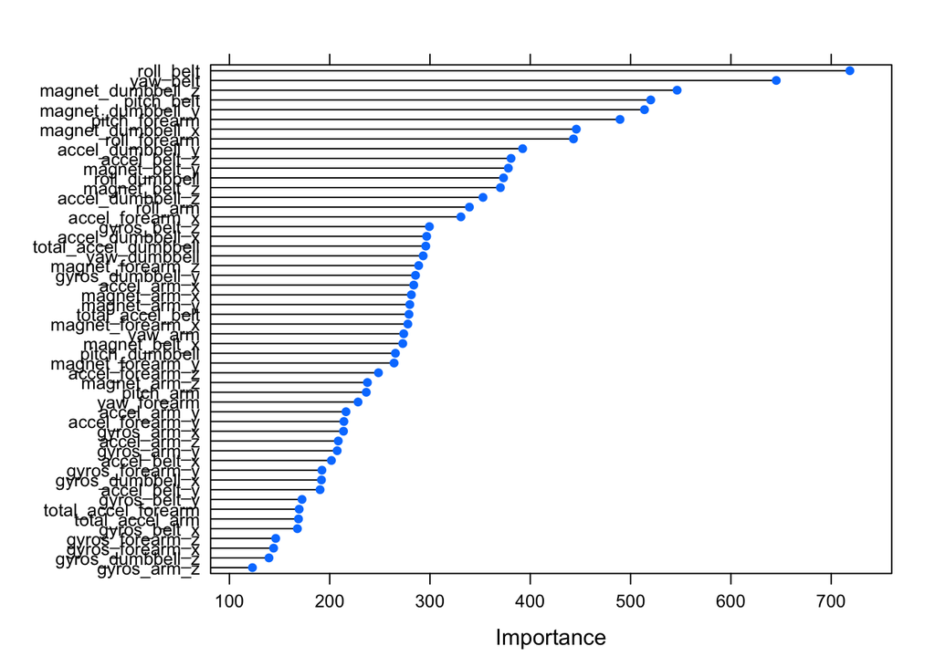

```r
# plot importance
plot(importance)
```

```r
confusionMatrix(training$classe,predict(rfFit1,training))
```

```
## Confusion Matrix and Statistics
##
##           Reference
## Prediction    A    B    C    D    E
##          A 5580    0    0    0    0
##          B    0 3797    0    0    0
##          C    0    0 3422    0    0
##          D    0    0    0 3216    0
##          E    0    0    0    0 3607
##
## Overall Statistics
##
##                Accuracy : 1
##                  95% CI : (0.9998, 1)
##     No Information Rate : 0.2844
##     P-Value [Acc > NIR] : < 2.2e-16
##
##                   Kappa : 1
##  Mcnemar's Test P-Value : NA
##
## Statistics by Class:
##
##                      Class: A Class: B Class: C Class: D Class: E
## Sensitivity            1.0000   1.0000   1.0000   1.0000   1.0000
## Specificity            1.0000   1.0000   1.0000   1.0000   1.0000
## Pos Pred Value         1.0000   1.0000   1.0000   1.0000   1.0000
## Neg Pred Value         1.0000   1.0000   1.0000   1.0000   1.0000
## Prevalence             0.2844   0.1935   0.1744   0.1639   0.1838
## Detection Rate         0.2844   0.1935   0.1744   0.1639   0.1838
## Detection Prevalence   0.2844   0.1935   0.1744   0.1639   0.1838
## Balanced Accuracy      1.0000   1.0000   1.0000   1.0000   1.0000
```

```r
table(prediction=predict(rfFit1, training), training$classe)
```

```
##
## prediction    A    B    C    D    E
##          A 5580    0    0    0    0
##          B    0 3797    0    0    0
##          C    0    0 3422    0    0
##          D    0    0    0 3216    0
##          E    0    0    0    0 3607
```

### prediction on the testing data set

**in sample error** = error resulted from applying your prediction algorithm to the dataset you built it with also known as resubstitution error.

**out of sample error** = error resulted from applying your prediction algorithm to a new data set also known as generalization error

The random forest model is very accurate on the training data sets, I expect: **in sample error < out of sample error**  
reason is over-fitting: model too adapted/optimized for the initial dataset

```r
predict(rfFit1, newdata = testing)
```

```
##  [1] B A B A A E D B A A B C B A E E A B B B
## Levels: A B C D E
```